# 여러 분포에 대한 설명과 예제

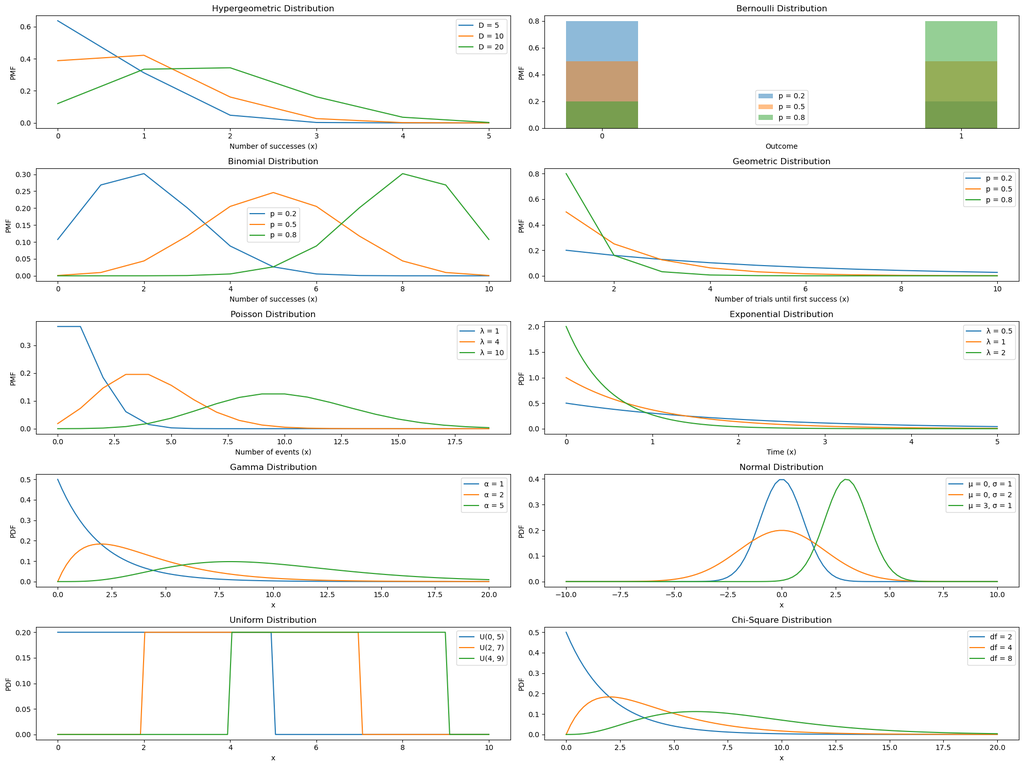

```python
# Re-running the code for visualization without download link request

import numpy as np
import matplotlib.pyplot as plt
from scipy.stats import hypergeom, bernoulli, binom, geom, poisson, expon, gamma, norm, uniform, chi2

# 그래프 크기 설정
plt.figure(figsize=(20, 15))

# 1. Hypergeometric Distribution (초기하분포)
plt.subplot(5, 2, 1)
N, D, n = 60, 10, 5  # 모집단 크기, 속성 개수, 샘플 크기
x = np.arange(0, n + 1)
for D_val in [5, 10, 20]:  # D값에 따른 변화
    pmf = hypergeom.pmf(x, N, D_val, n)
    plt.plot(x, pmf, label=f'D = {D_val}')
plt.title('Hypergeometric Distribution')
plt.xlabel('Number of successes (x)')
plt.ylabel('PMF')
plt.legend()

# 2. Bernoulli Distribution (베르누이 분포)
plt.subplot(5, 2, 2)
x = [0, 1]
for p in [0.2, 0.5, 0.8]:  # 성공 확률 p 변화
    pmf = bernoulli.pmf(x, p)
    plt.bar(x, pmf, alpha=0.5, label=f'p = {p}', width=0.2)
plt.title('Bernoulli Distribution')
plt.xlabel('Outcome')
plt.ylabel('PMF')
plt.xticks([0, 1])
plt.legend()

# 3. Binomial Distribution (이항분포)
plt.subplot(5, 2, 3)
n = 10  # 시행 수
x = np.arange(0, n + 1)
for p in [0.2, 0.5, 0.8]:  # 성공 확률 p 변화
    pmf = binom.pmf(x, n, p)
    plt.plot(x, pmf, label=f'p = {p}')
plt.title('Binomial Distribution')
plt.xlabel('Number of successes (x)')
plt.ylabel('PMF')
plt.legend()

# 4. Geometric Distribution (기하분포)
plt.subplot(5, 2, 4)
x = np.arange(1, 11)
for p in [0.2, 0.5, 0.8]:  # 성공 확률 p 변화
    pmf = geom.pmf(x, p)
    plt.plot(x, pmf, label=f'p = {p}')
plt.title('Geometric Distribution')
plt.xlabel('Number of trials until first success (x)')
plt.ylabel('PMF')
plt.legend()

# 5. Poisson Distribution (포아송 분포)
plt.subplot(5, 2, 5)
x = np.arange(0, 20)
for lam in [1, 4, 10]:  # 평균 발생 횟수 λ 변화
    pmf = poisson.pmf(x, lam)
    plt.plot(x, pmf, label=f'λ = {lam}')
plt.title('Poisson Distribution')
plt.xlabel('Number of events (x)')
plt.ylabel('PMF')
plt.legend()

# 6. Exponential Distribution (지수분포)
plt.subplot(5, 2, 6)
x = np.linspace(0, 5, 100)
for lam in [0.5, 1, 2]:  # λ 변화
    pdf = expon.pdf(x, scale=1/lam)
    plt.plot(x, pdf, label=f'λ = {lam}')
plt.title('Exponential Distribution')
plt.xlabel('Time (x)')
plt.ylabel('PDF')
plt.legend()

# 7. Gamma Distribution (감마분포)
plt.subplot(5, 2, 7)
x = np.linspace(0, 20, 100)
for alpha in [1, 2, 5]:  # α 변화
    pdf = gamma.pdf(x, a=alpha, scale=2)
    plt.plot(x, pdf, label=f'α = {alpha}')
plt.title('Gamma Distribution')
plt.xlabel('x')
plt.ylabel('PDF')
plt.legend()

# 8. Normal Distribution (정규분포)
plt.subplot(5, 2, 8)
x = np.linspace(-10, 10, 100)
for mu, sigma in [(0, 1), (0, 2), (3, 1)]:  # μ와 σ 변화
    pdf = norm.pdf(x, mu, sigma)
    plt.plot(x, pdf, label=f'μ = {mu}, σ = {sigma}')
plt.title('Normal Distribution')
plt.xlabel('x')
plt.ylabel('PDF')
plt.legend()

# 9. Uniform Distribution (균등분포)
plt.subplot(5, 2, 9)
x = np.linspace(0, 10, 100)
for a, b in [(0, 5), (2, 7), (4, 9)]:  # 구간 변화
    pdf = uniform.pdf(x, a, b - a)
    plt.plot(x, pdf, label=f'U({a}, {b})')
plt.title('Uniform Distribution')
plt.xlabel('x')
plt.ylabel('PDF')
plt.legend()

# 10. Chi-Square Distribution (카이제곱 분포)
plt.subplot(5, 2, 10)
x = np.linspace(0, 20, 100)
for df in [2, 4, 8]:  # 자유도 변화
    pdf = chi2.pdf(x, df)
    plt.plot(x, pdf, label=f'df = {df}')
plt.title('Chi-Square Distribution')
plt.xlabel('x')
plt.ylabel('PDF')
plt.legend()

plt.tight_layout()
plt.show()
```

## 1. 초기하분포 (Hypergeometric Distribution)

### 정의:

유한 모집단에서 비복원 추출(동시추출)을 할 때 사용할 수 있는 분포.

- N개의 유한 모집단, 속성을 가진 개수 D, n개를 단순 랜덤 추출
- $X = $ 속성을 가진 개체 수
- 확률 밀도 함수: $$ f(x) = \frac{\binom{D}{x} \binom{N-D}{n-x}}{\binom{N}{n}} \quad 0 \leq x \leq D, 0 \leq n-x \leq N-D $$
- 기호: $X \sim H(n; N, D)$

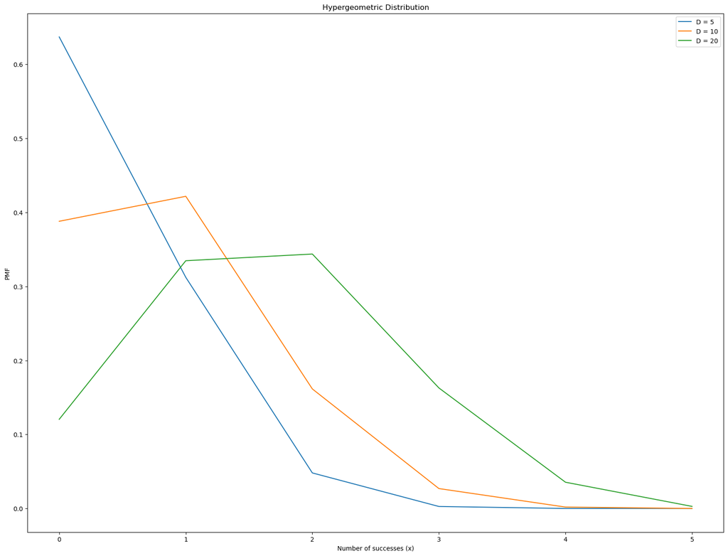

```python
import numpy as np
import matplotlib.pyplot as plt
from scipy.stats import hypergeom, bernoulli, binom, geom, poisson, expon, gamma, norm, uniform, chi2

# 그래프 크기 설정
plt.figure(figsize=(20, 15))

# 1. Hypergeometric Distribution (초기하분포)

N, D, n = 60, 10, 5  # 모집단 크기, 속성 개수, 샘플 크기
x = np.arange(0, n + 1)
for D_val in [5, 10, 20]:  # D값에 따른 변화
    pmf = hypergeom.pmf(x, N, D_val, n)
    plt.plot(x, pmf, label=f'D = {D_val}')
plt.title('Hypergeometric Distribution')
plt.xlabel('Number of successes (x)')
plt.ylabel('PMF')
plt.legend()
plt.show()
```

### 평균과 분산:

- $E(X) = \frac{n \cdot D}{N}$
- $Var(X) = \frac{n \cdot D}{N} \cdot \frac{N - D}{N} \cdot \frac{N - n}{N - 1}$

### 예제 3.1.1:

- **초기하분포**: 모집단에서 **비복원 추출**을 할 때 사용됩니다. 즉, 선택된 개체를 다시 모집단에 넣지 않고 표본을 추출하는 경우에 해당합니다.
- **이항분포**: 모집단에서 **복원 추출**을 할 때 사용됩니다. 즉, 선택된 개체를 다시 모집단에 넣고 독립적으로 표본을 추출하는 경우에 해당합니다.

초기하분포는 다음과 같은 조건을 가질 때 **이항분포로 근사**할 수 있습니다.

### 1. **초기하분포와 이항분포의 정의**

#### 초기하분포

초기하분포는 **유한한 모집단**에서 비복원 추출을 할 때 사용됩니다. 모집단의 크기를 $N$이라 하고, 그 중 성공을 나타내는 개체의 수를 $D$, 추출한 표본의 크기를 $n$이라 할 때, 초기하분포에서 성공한 개체의 수 $X$는 다음과 같은 확률 질량 함수(PMF)를 가집니다:

$$ P(X = k) = \frac{\binom{D}{k} \binom{N-D}{n-k}}{\binom{N}{n}}, \quad 0 \leq k \leq \min(D, n) $$

#### 이항분포

이항분포는 **무한히 큰 모집단**에서 복원 추출을 할 때 사용됩니다. 이항분포에서 $n$번의 독립적인 시도 중 성공할 확률이 $p$일 때, 성공 횟수 $X$는 다음과 같은 확률 질량 함수(PMF)를 가집니다:

$$ P(X = k) = \binom{n}{k} p^k (1 - p)^{n - k}, \quad 0 \leq k \leq n $$

### 2. **초기하분포의 이항분포 근사**

초기하분포는 모집단이 매우 크고, 표본의 크기 $n$이 모집단 크기 $N$에 비해 매우 작을 때 **이항분포로 근사**할 수 있습니다. 이 경우 각 시도는 거의 독립적인 것으로 간주될 수 있기 때문에 비복원 추출에서 복원 추출로의 변환이 가능해집니다. 이는 다음 조건을 만족할 때 이항근사가 가능합니다:

- **모집단이 매우 큰 경우**: $N \gg n$
- **성공률 $p$가 일정한 경우**: $p = \frac{D}{N}$

이러한 경우, 초기하분포는 이항분포 $X \sim \text{Binomial}(n, p)$로 근사할 수 있습니다.

### 3. **이항근사 공식**

초기하분포의 성공률 $p = \frac{D}{N}$을 기반으로 이항분포로 근사할 수 있습니다:

$$ P(X = k) \approx \binom{n}{k} \left(\frac{D}{N}\right)^k \left(1 - \frac{D}{N}\right)^{n-k} $$

### 4. **초기하분포와 이항분포의 차이**

- **복원 vs 비복원 추출**: 초기하분포는 비복원 추출로, 각 표본 추출이 독립적이지 않습니다. 이항분포는 복원 추출로, 표본 추출이 독립적입니다.
- **모집단 크기**: 초기하분포는 유한한 모집단 크기를 고려하는 반면, 이항분포는 사실상 무한히 큰 모집단을 가정합니다.
- **근사 가능성**: 모집단 크기 $N$이 매우 크고, 표본 크기 $n$이 상대적으로 작을 때, 초기하분포는 이항분포로 근사할 수 있습니다.

### 5. **예제**

예를 들어, $N = 1000$, $D = 100$인 모집단에서 $n = 10$개의 표본을 비복원 추출한다고 가정할 때, 초기하분포의 성공 확률을 계산할 수 있습니다. 이 경우 모집단 크기 $N$이 크므로, 이 표본 추출을 이항분포로 근사할 수 있습니다. 이항분포에서 성공 확률 $p = \frac{D}{N} = 0.1$로 간주하여 이항분포 $X \sim \text{Binomial}(10, 0.1)$을 사용할 수 있습니다.

### 6. **결론**

초기하분포는 모집단의 크기가 유한하고, 표본 추출이 비복원적으로 이루어지는 경우에 사용됩니다. 하지만 모집단 크기가 매우 크고, 표본의 크기가 작다면 초기하분포는 이항분포로 근사할 수 있습니다. 이 경우 성공 확률을 $p = \frac{D}{N}$으로 설정하여 이항분포로 간단히 계산할 수 있습니다.

## 2. 베르누이 분포 (Bernoulli Distribution)

- 베르누이 시행: {성공, 실패} 또는 {0, 1}의 결과를 갖는 실험
- 베르누이 분포는 성공 확률이 $p$, 실패 확률이 $1-p$인 경우

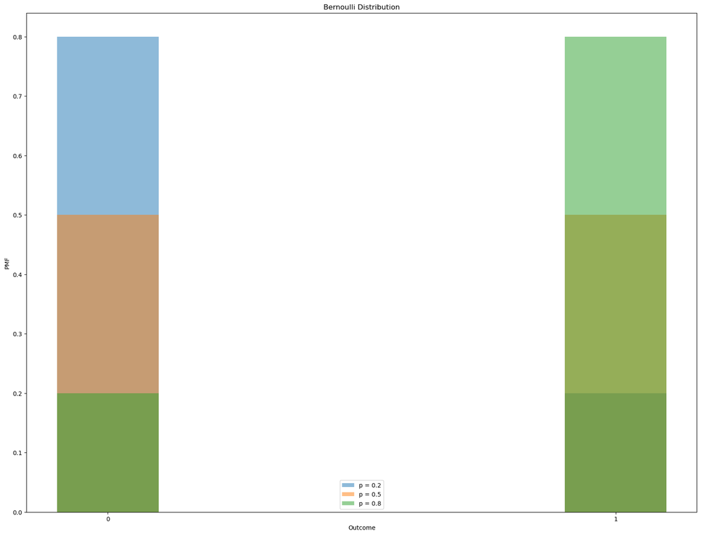

```python
# 2. Bernoulli Distribution (베르누이 분포)
# 그래프 크기 설정
plt.figure(figsize=(20, 15))

x = [0, 1]
for p in [0.2, 0.5, 0.8]:  # 성공 확률 p 변화
    pmf = bernoulli.pmf(x, p)
    plt.bar(x, pmf, alpha=0.5, label=f'p = {p}', width=0.2)
plt.title('Bernoulli Distribution')
plt.xlabel('Outcome')
plt.ylabel('PMF')
plt.xticks([0, 1])
plt.legend()
plt.show()
```

### 이항분포 (Binomial Distribution)

- n번 독립적인 베르누이 시행에서 성공 횟수를 따르는 분포 $$ f(x) = \binom{n}{x} p^x (1-p)^{n-x}, \quad x = 0, 1, \dots, n $$
- 기호: $X \sim B(n, p)$
- 평균과 분산:
  - $E(X) = np$
  - $Var(X) = np(1-p)$

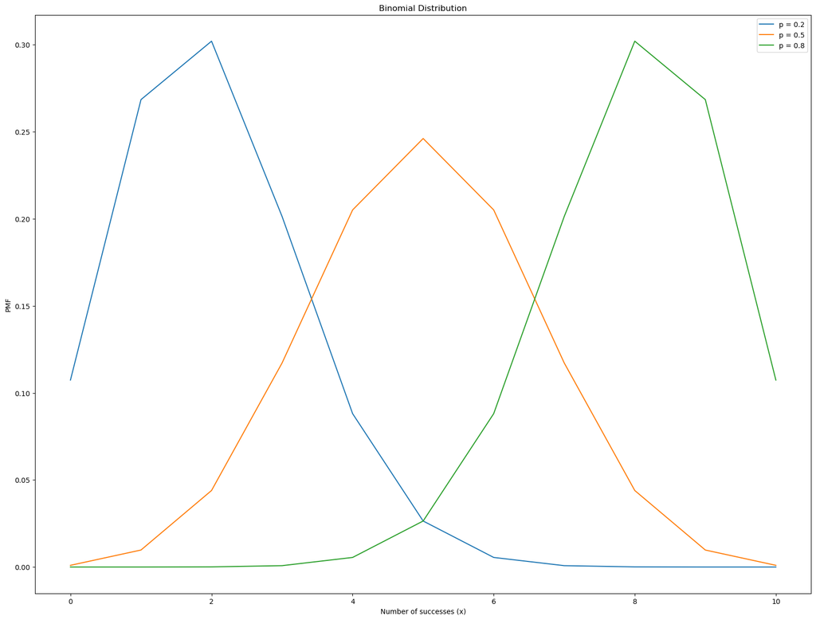

```python
# 3. Binomial Distribution (이항분포)
# 그래프 크기 설정
plt.figure(figsize=(20, 15))

n = 10  # 시행 수
x = np.arange(0, n + 1)
for p in [0.2, 0.5, 0.8]:  # 성공 확률 p 변화
    pmf = binom.pmf(x, n, p)
    plt.plot(x, pmf, label=f'p = {p}')
plt.title('Binomial Distribution')
plt.xlabel('Number of successes (x)')
plt.ylabel('PMF')
plt.legend()
plt.show()
```

### 1. **이항분포와 베르누이분포**

이항분포는 여러 번의 독립적인 베르누이 시행을 수행할 때 성공 횟수를 따르는 분포입니다.

- **이항분포의 정의**: $$ X \sim B(n, p) $$ 여기서 $n$은 시행 횟수, $p$는 성공 확률입니다. 이항분포는 $n$번의 독립적인 베르누이 시행의 합입니다.

  $$ X = \sum_{i=1}^{n} Z_i, \quad Z_i \sim \text{iid } B(1, p) $$

  각 $Z_i$는 독립적으로 동일한 베르누이 분포를 따르는 변수입니다. 즉, $Z_i \sim B(1, p)$는 성공 확률이 $p$, 실패 확률이 $1 - p$인 베르누이 시행입니다.
- **이항분포와 베르누이분포의 관계**:
  - **이항분포**는 여러 번의 베르누이 시행에서 성공한 횟수를 따르는 분포입니다. 예를 들어, 주사위를 던져서 특정 값이 나오는 확률을 여러 번 측정하는 경우에 이항분포가 적용됩니다.
  - **베르누이분포**는 단 한 번의 시행에서 성공 또는 실패를 구분하는 분포입니다.

  이항분포는 여러 개의 독립적인 베르누이 분포의 합으로 구성됩니다.
- **이항분포의 평균과 분산**:
  - 이항분포의 평균은 $n \cdot p$입니다.
  - 이항분포의 분산은 $n \cdot p \cdot (1 - p)$, 즉 $n \cdot p \cdot q$입니다.
    - 여기서 $q = 1 - p$는 실패 확률입니다.

### 2. **이항분포의 성질 (정리 3.2.1)**

이항분포에 대한 중요한 성질이 몇 가지 있습니다.

- **적률 생성 함수 (MGF, Moment Generating Function)**: $$ M(t) = (pe^t + q)^n $$

  적률 생성 함수는 확률 분포의 성질을 나타내는 중요한 함수로, 확률 변수의 모든 적률(평균, 분산 등)를 구할 수 있는 정보가 담겨 있습니다. 이항분포의 MGF는 위와 같이 표현됩니다.
  - $p$: 성공 확률
  - $q = 1 - p$: 실패 확률
  - $n$: 시행 횟수
  - $t$: 적률 생성 함수의 변수

  이 함수를 통해 이항분포의 평균, 분산, 고차 적률를 계산할 수 있습니다.
- **독립적인 이항분포의 합**:

  $$ X_1 \sim B(n_1, p), X_2 \sim B(n_2, p) $$ 두 개의 독립적인 이항분포를 합할 경우, 그 결과는 또 다른 이항분포가 됩니다.

  $$ X_1 + X_2 \sim B(n_1 + n_2, p) $$

  이 성질은 이항분포의 중요한 성질 중 하나로, 독립적인 이항 시행들을 더하면 또 다른 이항분포를 따른다는 것을 의미합니다. 이 성질은 여러 번의 독립적인 실험에서 발생한 성공 횟수를 하나의 분포로 묶을 때 유용합니다.

### 요약

1. **이항분포**는 여러 번의 독립적인 베르누이 시행에서 성공한 횟수를 따르는 분포입니다. 이항분포는 여러 개의 베르누이 시행의 합으로 구성됩니다.
2. 이항분포의 평균은 $n \cdot p$, 분산은 $n \cdot p \cdot q$입니다.
3. **적률 생성 함수**는 이항분포의 성질을 분석하는 데 유용하며, 이는 $M(t) = (pe^t + q)^n$으로 표현됩니다.
4. **독립적인 이항분포의 합**은 또 다른 이항분포를 따릅니다.

### 3. 이항분포의 MGF 유도

이항분포에서 확률변수 $X$의 MGF는 확률 질량 함수(PMF)를 이용하여 다음과 같이 구할 수 있습니다:

$$ M_X(t) = E(e^{tX}) = \sum_{k=0}^{n} e^{tk} P(X = k) $$

이항분포의 PMF $P(X = k)$를 대입하면:

$$ M_X(t) = \sum_{k=0}^{n} e^{tk} \binom{n}{k} p^k q^{n-k} $$

이 식은 $e^{tk}$와 $p^k$를 묶어 다음과 같이 변형할 수 있습니다:

$$ M_X(t) = \sum_{k=0}^{n} \binom{n}{k} (p e^t)^k q^{n-k} $$

### 4. 이항정리 적용

이항정리에 따르면, 다음과 같은 합이 성립합니다:

$$ \sum_{k=0}^{n} \binom{n}{k} a^k b^{n-k} = (a + b)^n $$

위 식에 이항정리를 적용하면:

$$ M_X(t) = (p e^t + q)^n $$

즉, 이항분포 $X \sim B(n, p)$의 적률 생성 함수는 다음과 같습니다:

$$ M_X(t) = (pe^t + q)^n $$

### 5. MGF를 이용한 평균과 분산 계산

이제 MGF를 사용하여 이항분포의 평균과 분산을 구할 수 있습니다.

- **평균**은 MGF의 1차 미분을 $t=0$에서 계산한 값입니다: $$ E(X) = M'_X(0) $$
- **분산**은 MGF의 2차 미분을 $t=0$에서 계산한 값에서 평균의 제곱을 뺀 값입니다: $$ \text{Var}(X) = M''_X(0) - [E(X)]^2 $$

### 결론

이항분포의 적률 생성 함수는 다음과 같이 유도됩니다:

$$ M_X(t) = (pe^t + q)^n $$

이 식을 이용해 평균과 분산을 포함한 모든 적률를 계산할 수 있습니다.

**확률변수 합의 mgf는 mgf의 곱이다.**

## 이항분포의 평균을 구하는 방법 3가지

### 1. **기대값의 정의를 이용한 방법**

기대값(평균)은 확률변수의 값을 확률과 곱한 후 합산한 값입니다. 이항분포의 확률질량함수(PMF)는 다음과 같습니다:

$$ P(X = k) = \binom{n}{k} p^k (1 - p)^{n - k}, \quad k = 0, 1, \dots, n $$

기대값은 다음과 같이 정의됩니다:

$$ E(X) = \sum_{k=0}^{n} k \cdot P(X = k) $$

이항분포에 대해 이 식을 적용하면:

$$ E(X) = \sum_{k=0}^{n} k \binom{n}{k} p^k (1 - p)^{n - k} $$

이항분포의 성질과 대수적 변형을 통해 이 식을 계산하면, 평균은 다음과 같이 간단히 정리됩니다:

$$ E(X) = n \cdot p $$

따라서 이항분포의 평균은 시행 횟수 $n$과 성공 확률 $p$의 곱과 같습니다.

### 2. **적률 생성 함수를 이용한 방법**

적률 생성 함수(MGF, Moment Generating Function)를 사용하여 평균을 구할 수 있습니다. 적률 생성 함수는 다음과 같이 정의됩니다:

$$ M_X(t) = E(e^{tX}) $$

이항분포 $X \sim B(n, p)$의 적률 생성 함수는 다음과 같습니다:

$$ M_X(t) = (pe^t + (1 - p))^n $$

평균은 적률 생성 함수의 첫 번째 미분을 구하고, $t = 0$을 대입한 값으로 정의됩니다:

$$ E(X) = M'_X(0) $$

먼저 $M_X(t)$에 대해 미분을 합니다:

$$ M'_X(t) = n \cdot (pe^t + (1 - p))^{n-1} \cdot p \cdot e^t $$

이제 $t = 0$을 대입합니다:

$$ M'_X(0) = n \cdot (p + (1 - p))^{n-1} \cdot p = n \cdot p $$

따라서, 이항분포의 평균은 $n \cdot p$입니다.

### 3. **베르누이 분포의 합을 이용한 방법**

이항분포는 여러 번의 독립적인 베르누이 시행의 합으로 정의될 수 있습니다. 즉, 이항분포 $X \sim B(n, p)$는 $n$개의 베르누이 시행의 합으로 표현됩니다:

$$ X = Z_1 + Z_2 + \dots + Z_n, \quad Z_i \sim B(1, p) $$

베르누이 분포 $Z_i \sim B(1, p)$의 기대값은:

$$ E(Z_i) = p $$

여기서 $X$는 $n$개의 독립적인 베르누이 시행의 합이므로, 이항분포의 기대값 $E(X)$는 다음과 같이 표현할 수 있습니다:

$$ E(X) = E(Z_1 + Z_2 + \dots + Z_n) $$

독립 변수들의 기대값의 합은 각 기대값의 합과 같으므로:

$$ E(X) = E(Z_1) + E(Z_2) + \dots + E(Z_n) = n \cdot p $$

따라서, 이항분포의 평균은 $n \cdot p$입니다.

### 결론

이항분포의 평균을 구하는 3가지 방법은 다음과 같습니다:

1. **기대값의 정의**를 이용하여 직접 계산하는 방법: $E(X) = \sum_{k=0}^{n} k \cdot P(X = k)$.
2. **적률 생성 함수**를 이용하여 첫 번째 미분을 구하는 방법: $M'_X(0) = n \cdot p$.
3. **베르누이 시행의 합**을 이용하여 각각의 평균을 더하는 방법: $E(X) = n \cdot p$.

세 가지 방법 모두 이항분포의 평균이 $n \cdot p$임을 보여줍니다.

## 3. 기하분포 (Geometric Distribution)

- 베르누이 시행을 독립적으로 반복할 때, 첫 성공까지의 시행 횟수에 대한 분포 $$ f(x) = (1-p)^{x-1} p, \quad x = 1, 2, \dots $$
- 기호: $W_1 \sim Geo(p)$

### 1. **적률 생성 함수 $ M(t) $**

적률 생성 함수(Moment Generating Function, MGF)는 다음과 같이 정의됩니다:

$$ M(t) = E(e^{tX}) $$

기하분포에서 성공 확률이 $ p $이고, 실패 확률이 $ q = 1 - p $일 때, 첫 성공까지 걸리는 시행 횟수 $ W_1 $는 다음과 같은 적률 생성 함수를 가집니다.

$$ M(t) = \sum_{x=1}^{\infty} e^{tx} pq^{x-1} $$

이 식을 해석해 보면, 각 시도에서 성공 확률 $ p $와 실패 확률 $ q^{x-1} $을 가진 시행에서 $ e^{tx} $를 곱해준 것입니다. 기하급수의 성질을 이용하여 이 식을 풀어봅니다:

1. $ p \cdot e^t $를 밖으로 빼면, 다음과 같은 기하급수가 남습니다:

$$ M(t) = p \cdot e^t \sum_{x=1}^{\infty} (q e^t)^{x-1} $$

2. 이 식은 기하급수의 합 공식:

$$ \sum_{x=0}^{\infty} r^x = \frac{1}{1 - r}, \quad \text{(단, } |r| < 1 \text{)} $$

을 사용하여 풀 수 있습니다. 여기서 $ r = q e^t $로 대입하면:

$$ M(t) = \frac{p \cdot e^t}{1 - q e^t} $$

따라서, 기하분포의 적률 생성 함수는 다음과 같이 정리됩니다:

$$ M(t) = \frac{p \cdot e^t}{1 - q e^t} $$

### 2. **기하분포의 기대값 $ E(W_1) $**

기하분포의 기대값(평균)을 구하기 위해 적률 생성 함수의 첫 번째 미분을 사용합니다.

기대값은 적률 생성 함수의 첫 번째 미분을 $ t = 0 $에서 계산한 값입니다:

$$ E(W_1) = M'(0) $$

먼저 적률 생성 함수를 미분합니다:

$$ M'(t) = \frac{d}{dt} \left( \frac{p \cdot e^t}{1 - q e^t} \right) $$

이를 미분하면:

$$ M'(t) = \frac{p \cdot e^t (1 - q e^t) - p \cdot e^t \cdot q \cdot e^t}{(1 - q e^t)^2} = \frac{p \cdot e^t}{(1 - q e^t)^2} $$

이제 $ t = 0 $을 대입하면:

$$ M'(0) = \frac{p \cdot e^0}{(1 - q e^0)^2} = \frac{p}{(1 - q)^2} = \frac{p}{p^2} = \frac{1}{p} $$

따라서, 기하분포의 기대값은:

$$ E(W_1) = \frac{1}{p} $$

### 3. **기하분포의 분산 $ \text{Var}(W_1) $**

기하분포의 분산은 적률 생성 함수의 두 번째 미분과 첫 번째 미분을 사용하여 구할 수 있습니다.

분산은 다음과 같이 정의됩니다:

$$ \text{Var}(W_1) = M''(0) - [M'(0)]^2 $$

1. **두 번째 미분**을 구합니다:

$$ M''(t) = \frac{d}{dt} \left( \frac{p \cdot e^t}{(1 - q e^t)^2} \right) $$

이를 미분하면:

$$ M''(t) = \frac{p \cdot e^t (1 - q e^t)^2 - 2p \cdot e^{2t} q (1 - q e^t)}{(1 - q e^t)^4} $$

여기서 $ t = 0 $을 대입하면:

2. 이제 분산을 구하면:

$$ \text{Var}(W_1) = M''(0) - [M'(0)]^2 = \frac{1}{p^2} - \left(\frac{1}{p}\right)^2 = \frac{q}{p^2} $$

따라서 기하분포의 분산은:

$$ \text{Var}(W_1) = \frac{q}{p^2} $$

### 요약

1. **적률 생성 함수**: 기하분포의 적률 생성 함수는 다음과 같이 표현됩니다: $$ M(t) = \frac{p \cdot e^t}{1 - q e^t} $$
2. **기대값**: 기하분포에서 첫 성공까지 걸리는 시행 횟수의 기대값은 성공 확률 $ p $의 역수로 표현됩니다: $$ E(W_1) = \frac{1}{p} $$
3. **분산**: 기하분포의 분산은 다음과 같이 구할 수 있습니다: $$ \text{Var}(W_1) = \frac{q}{p^2}, \quad q = 1 - p $$

### 2. **기하분포의 비기억성(Memoryless Property)**

기하분포는 **비기억성**을 가집니다. 이는 이전의 시행 결과와 상관없이 남은 시도에서 성공할 확률이 항상 동일하다는 의미입니다. 수학적으로, 비기억성은 다음과 같이 표현됩니다:

$$ P(X > i + j \mid X > i) = P(X > j) $$

즉, $i$번 시도 이후에도 성공이 발생하지 않았을 때, 추가로 $j$번 이상의 시도가 더 필요할 확률은 $j$번 이상의 시도가 처음부터 필요할 확률과 동일합니다.

### 3. **비기억성의 증명**

비기억성은 다음과 같이 증명할 수 있습니다:

1. 우선 $P(X > x)$는 $x$번째 시도까지 모두 실패할 확률입니다. 따라서:

$$ P(X > x) = q^x $$

2. $P(X > i + j \mid X > i)$는 $i$번째 시도 이후 추가로 $j$번 이상의 시도가 더 필요할 조건부 확률입니다. 조건부 확률의 정의에 따라 다음과 같이 표현됩니다:

$$ P(X > i + j \mid X > i) = \frac{P(X > i + j \text{ and } X > i)}{P(X > i)} = \frac{P(X > i + j)}{P(X > i)} $$

3. 각각의 확률을 대입하면:

$$ P(X > i + j \mid X > i) = \frac{q^{i + j}}{q^i} = q^j $$

이로써, $P(X > i + j \mid X > i) = P(X > j)$임을 알 수 있습니다. 이는 **기하분포가 비기억성**을 가진다는 것을 수학적으로 증명한 것입니다.

### 4. **비기억성의 의미**

- 일정 기간(예: $i$번의 시도)이 지나도 성공이 발생하지 않았을 때, 그 이후에 성공까지 추가로 $j$번 이상의 시도가 더 필요할 확률은 처음부터 $j$번 이상의 시도가 필요할 확률과 동일합니다.
- 즉, 기하분포에서는 이전에 몇 번 실패했는지와 상관없이, 남은 시도에서 성공할 확률은 동일하다는 점을 의미합니다.

이 특성 때문에, 기하분포는 대기 시간이나 첫 번째 성공까지의 시도를 모델링하는 데 매우 유용합니다.

### 요약

- **기하분포**는 성공 확률 $p$로 독립적인 시행을 반복할 때 첫 번째 성공까지 걸리는 시행 횟수를 나타내는 분포입니다.
- **비기억성**이란, 일정 시도 이후에도 성공이 발생하지 않았을 때 추가로 성공까지 걸리는 시간이 이전 시행 결과와 무관하다는 것을 의미합니다.
- **수학적으로** $P(X > i + j \mid X > i) = P(X > j)$로 표현되며, 이는 기하분포의 중요한 성질입니다.

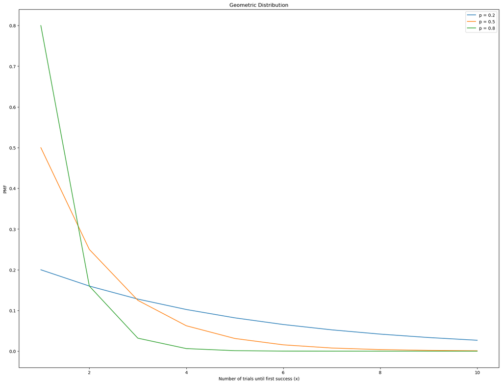

```python
# 4. Geometric Distribution (기하분포)
# 그래프 크기 설정
plt.figure(figsize=(20, 15))

x = np.arange(1, 11)
for p in [0.2, 0.5, 0.8]:  # 성공 확률 p 변화
    pmf = geom.pmf(x, p)
    plt.plot(x, pmf, label=f'p = {p}')
plt.title('Geometric Distribution')
plt.xlabel('Number of trials until first success (x)')
plt.ylabel('PMF')
plt.legend()
plt.show()
```

### 1. **음이항분포의 정의**

- **음이항분포**는 성공 확률 $ p $인 베르누이 시행을 독립적으로 반복할 때, **r번째 성공이 발생할 때까지의 시행 횟수**를 나타내는 분포입니다.
- **표기법**: 음이항분포는 $ W_r \sim \text{NegBin}(r, p) $ 또는 $ W_r \sim \text{NB}(r, p) $로 표기됩니다. 여기서:
  - $ r $: 성공해야 하는 횟수
  - $ p $: 각 시행에서의 성공 확률
  - $ q = 1 - p $: 실패 확률
- **확률질량함수(PMF)**:

  음이항분포에서 $ W_r = x $일 확률은 다음과 같이 정의됩니다:

  $$ f(x) = \binom{x-1}{r-1} q^{x - r} p^r, \quad x = r, r+1, r+2, \dots $$

  여기서 $ x $는 $ r $번째 성공이 나올 때까지의 총 시행 횟수입니다. 즉, 총 $ x $번의 시행에서 $ r $번 성공하고 나머지는 실패하는 경우를 다룹니다.

### 2. **대의적 정의**

음이항분포는 여러 개의 독립적인 기하분포 시행의 합으로도 정의할 수 있습니다. 즉, $ W_r $는 다음과 같이 정의됩니다:

$$ W_r = \sum_{i=1}^{r} X_i, \quad X_i \sim G(p) $$

여기서 $ G(p) $는 기하분포를 의미합니다. 즉, 음이항분포는 $ r $번의 기하분포 시행에서 각각 첫 성공까지 걸린 시행 횟수들의 합으로 정의될 수 있습니다.

### 3. **음이항분포의 성질**

- **적률 생성 함수 (MGF)**:

  음이항분포의 적률 생성 함수는 기하분포의 MGF를 사용하여 유도됩니다. 음이항분포는 여러 번의 기하분포 시행의 합으로 나타낼 수 있으므로, 다음과 같이 적률 생성 함수를 표현할 수 있습니다:

  $$ M(t) = \left( \frac{p e^t}{1 - q e^t} \right)^r $$

  이는 기하분포의 적률 생성 함수를 거듭제곱한 형태입니다.
- **기대값과 분산**:

  음이항분포의 기대값과 분산은 다음과 같습니다:
  - **기대값**: $$ E(W_r) = \frac{r}{p} $$ 이는 $ r $번 성공하기 위해 필요한 평균 시행 횟수를 의미합니다.
  - **분산**: $$ \text{Var}(W_r) = \frac{r q}{p^2} $$ 이는 시행 횟수의 분산을 나타냅니다.
- **음이항분포의 가법성**:

  음이항분포는 기하분포와 마찬가지로 **가법성**(Additivity)을 가집니다. 즉, 두 개의 독립적인 음이항분포의 합도 또 다른 음이항분포를 따릅니다. 이는 대의적 정의나 적률 생성 함수(MGF)를 사용하여 증명할 수 있습니다.

### 4. **기하분포와의 관계**

- **음이항분포는 기하분포의 일반화**입니다. 기하분포는 첫 번째 성공까지 걸리는 시행 횟수를 다루는 분포인 반면, 음이항분포는 $ r $번 성공할 때까지 걸리는 시행 횟수를 다룹니다.
- 음이항분포에서 $ r = 1 $인 경우, 이는 기하분포와 동일합니다. 즉, 기하분포는 음이항분포의 특수한 경우로 볼 수 있습니다.

### 요약

1. **음이항분포** 는 $ r $번 성공할 때까지의 시행 횟수를 나타내는 분포입니다. 이는 성공 확률 $ p $를 가지는 베르누이 시행을 독립적으로 반복하는 과정에서 사용됩니다.
2. 음이항분포의 **확률질량함수(PMF)** 는 총 시행 횟수 $ x $에서 $ r $번 성공할 확률을 나타내며, $ f(x) = \binom{x-1}{r-1} q^{x-r} p^r $로 주어집니다.
3. 음이항분포의 **적률 생성 함수(MGF)** 는 $ M(t) = \left( \frac{p e^t}{1 - q e^t} \right)^r $로 표현되며, 이를 통해 평균과 분산을 구할 수 있습니다.
4. 음이항분포의 **기대값** 은 $ \frac{r}{p} $, **분산** 은 $ \frac{r q}{p^2} $입니다.
5. 음이항분포는 **가법성** 을 가지며, 여러 음이항분포를 합친 것도 또 다른 음이항분포를 따릅니다.

음이항분포는 성공 횟수를 목표로 하는 실험이나 반복 과정에서 매우 유용한 분포입니다.

## 4. 포아송 분포 (Poisson Distribution)

- 단위 시간 동안 평균적으로 $\lambda$번 사건이 발생할 때, 사건의 수를 따르는 분포 $$ f(x) = \frac{e^{-\lambda} \lambda^x}{x!}, \quad x = 0, 1, 2, \dots $$
- 기호: $X \sim \text{Poisson}(\lambda)$ 또는 $\text{Poi}(\lambda)$
- 평균과 분산:
  - $E(X) = \lambda$
  - $Var(X) = \lambda$

### 1. **포아송 분포의 적률 생성 함수 (MGF)**

포아송 분포의 적률 생성 함수(Moment Generating Function, MGF)는 확률 변수 $ X $의 모든 적률를 구하는 데 사용할 수 있습니다. 포아송 분포에서 확률 변수 $ X $는 단위 시간당 평균적으로 $ \lambda $번 발생하는 사건의 수를 나타냅니다.

포아송 분포의 적률 생성 함수는 다음과 같이 주어집니다:

$$ M(t) = E(e^{tX}) = \exp(\lambda(e^t - 1)) $$

#### 유도 과정:

1. 포아송 분포의 확률 질량 함수(PMF)는 다음과 같습니다: $$ P(X = k) = \frac{\lambda^k e^{-\lambda}}{k!}, \quad k = 0, 1, 2, \dots $$
2. 적률 생성 함수는 $ e^{tX} $의 기대값으로 정의됩니다: $$ M(t) = E(e^{tX}) = \sum_{k=0}^{\infty} e^{tk} \frac{\lambda^k e^{-\lambda}}{k!} $$
3. 이를 정리하면 다음과 같습니다: $$ M(t) = e^{-\lambda} \sum_{k=0}^{\infty} \frac{(\lambda e^t)^k}{k!} $$
4. 위의 합은 지수 함수의 테일러 급수와 동일하므로: $$ M(t) = e^{-\lambda} \cdot e^{\lambda e^t} = \exp(\lambda(e^t - 1)) $$

따라서 포아송 분포의 적률 생성 함수는 $ M(t) = \exp(\lambda(e^t - 1)) $로 표현됩니다.

### 2. **포아송 분포의 기대값과 분산**

- **기대값**:

  기대값 $ E(X) $는 적률 생성 함수의 첫 번째 미분을 $ t = 0 $에서 계산한 값으로 구할 수 있습니다:

  $$ E(X) = M'(0) $$

  포아송 분포의 MGF $ M(t) = \exp(\lambda(e^t - 1)) $를 미분한 후 $ t = 0 $을 대입하면 다음과 같이 계산됩니다:

  $$ M'(t) = \lambda e^t \exp(\lambda(e^t - 1)) $$

  여기서 $ t = 0 $을 대입하면:

  $$ M'(0) = \lambda $$

  따라서, 포아송 분포의 기대값은 $ \lambda $입니다.
- **분산**:

  포아송 분포의 분산은 적률 생성 함수의 두 번째 미분을 $ t = 0 $에서 계산한 값으로 구할 수 있습니다:

  $$ \text{Var}(X) = M''(0) - [M'(0)]^2 $$

  포아송 분포의 두 번째 미분은 다음과 같이 계산됩니다:

  $$ M''(t) = \lambda e^t (\lambda e^t + 1) \exp(\lambda(e^t - 1)) $$

  여기서 $ t = 0 $을 대입하면:

  따라서, 포아송 분포의 분산은 $ \lambda $입니다.

  결론적으로, 포아송 분포의 기대값과 분산은 모두 $ \lambda $입니다: $$ E(X) = \lambda, \quad \text{Var}(X) = \lambda $$

### 3. **포아송 분포의 가법성 (Additivity)**

포아송 분포는 **가법성**(Additivity) 성질을 가집니다. 이는 두 개 이상의 독립적인 포아송 분포를 합한 경우, 그 결과도 포아송 분포를 따른다는 것을 의미합니다.

- **가법성 성질**: $$ X_1 \sim \text{Poisson}(\lambda_1), \quad X_2 \sim \text{Poisson}(\lambda_2) $$

  두 개의 독립적인 포아송 분포가 있을 때, 이들의 합 $ X_1 + X_2 $도 포아송 분포를 따르며, 그 파라미터는 두 분포의 파라미터의 합입니다:

  $$ X_1 + X_2 \sim \text{Poisson}(\lambda_1 + \lambda_2) $$

이 성질은 포아송 분포가 사건 발생 횟수를 다룬다는 점에서 직관적입니다. 예를 들어, 두 개의 독립적인 시스템에서 발생하는 사건 수를 더하면 전체 사건 수는 두 시스템에서 발생한 사건 수의 합이 됩니다.

### 요약

1. **적률 생성 함수 (MGF)**: 포아송 분포의 적률 생성 함수는 다음과 같습니다: $$ M(t) = \exp(\lambda(e^t - 1)) $$
2. **기대값과 분산**: 포아송 분포의 기대값과 분산은 모두 $ \lambda $입니다: $$ E(X) = \lambda, \quad \text{Var}(X) = \lambda $$
3. **가법성 성질**: 두 개의 독립적인 포아송 분포의 합은 또 다른 포아송 분포를 따릅니다. 파라미터는 각각의 파라미터의 합입니다: $$ X_1 + X_2 \sim \text{Poisson}(\lambda_1 + \lambda_2) $$

포아송 분포는 사건이 일정한 시간이나 공간 내에서 발생할 때 그 사건 수를 모델링하는 데 매우 유용한 분포입니다.

### 1. **이항분포의 포아송 근사**

이항분포 $ X \sim B(n, p) $는 $ n $번의 독립적인 시행에서 성공 확률이 $ p $인 시행에서 성공 횟수를 나타내는 분포입니다. 이항분포의 확률 질량 함수(PMF)는 다음과 같습니다:

$$ P(X = x) = \binom{n}{x} p^x (1 - p)^{n - x}, \quad x = 0, 1, 2, \dots, n $$

포아송 근사는 다음 조건에서 성립합니다:

- **$ n $이 매우 크고** (즉, 시행 횟수가 많고)
- **$ p $가 매우 작으며** (즉, 사건 발생 확률이 낮고)
- **$ np = \lambda $로 일정** (즉, 평균 사건 발생 횟수가 일정)

이 조건이 충족되면, 이항분포는 포아송 분포로 근사될 수 있습니다. 이때 포아송 분포의 파라미터는 $ \lambda = np $가 됩니다.

#### 이항분포에서 포아송 분포로 근사되는 과정:

- **이항분포 $ X \sim B(n, p) $** 에서, $ n $이 커지고 $ p $가 작아지며 $ np = \lambda $일 때, 이항분포는 다음과 같이 변형됩니다:

$$ P(X = x) = \binom{n}{x} p^x (1 - p)^{n - x} $$

- $ n $이 매우 크고 $ p $가 매우 작을 때, 이항분포의 확률 질량 함수는 다음과 같이 근사됩니다:

$$ P(X = x) \approx \frac{\lambda^x e^{-\lambda}}{x!} $$

이 식은 바로 포아송 분포의 확률 질량 함수입니다.

따라서, 이항분포는 $ n $이 매우 크고, 성공 확률 $ p $가 작으며, $ np = \lambda $가 일정할 때 **포아송 분포** $ X \sim \text{Poisson}(\lambda) $로 근사될 수 있습니다.

### 2. **포아송 과정 (Poisson Process)**

포아송 분포는 일반적으로 **포아송 과정**과 관련이 있습니다. 포아송 과정은 일정 시간 간격 동안 사건이 발생하는 횟수를 모델링하는 데 사용됩니다. 포아송 과정의 특징은 다음과 같습니다:

- **정상성 (Stationarity)**: 사건이 발생하는 평균 속도가 시간에 따라 변하지 않음을 의미합니다. 즉, 사건이 언제 발생하든지 간에 발생률이 일정합니다.
- **독립증분성 (Independent Increments)**: 한 구간에서 발생한 사건 수는 다른 구간에서 발생한 사건 수와 독립적입니다. 즉, 각 시간 구간에서 사건이 독립적으로 발생합니다.
- **비례성 (Proportionality)**: 짧은 시간 간격에서 사건이 발생할 확률은 시간 간격에 비례합니다. 시간 간격이 길어질수록 사건이 발생할 확률도 증가합니다.
- **희귀성 (Rarity)**: 매우 짧은 시간 간격에서 두 개 이상의 사건이 동시에 발생할 확률은 무시할 수 있을 만큼 작습니다.

포아송 분포는 포아송 과정의 사건 발생 횟수를 모델링하며, 이러한 성질들로 인해 포아송 분포는 여러 분야에서 발생 횟수를 다룰 때 유용하게 사용됩니다.

### 3. **요약**

- **이항분포의 포아송 근사**는 시행 횟수 $ n $이 매우 크고, 성공 확률 $ p $가 매우 작을 때 성립합니다. 이때 $ np = \lambda $일 경우, 이항분포는 포아송 분포로 근사할 수 있습니다. $$ P(X = x) \approx \frac{\lambda^x e^{-\lambda}}{x!} $$
- **포아송 과정**은 시간 간격에 따른 사건 발생을 모델링하는 데 사용되며, 정상성, 독립증분성, 비례성, 희귀성 등의 성질을 가집니다.

포아송 근사는 이항분포를 간단하게 계산할 수 있는 방법 중 하나로, 특히 사건 발생 확률이 매우 작은 대규모 데이터에서 유용합니다.

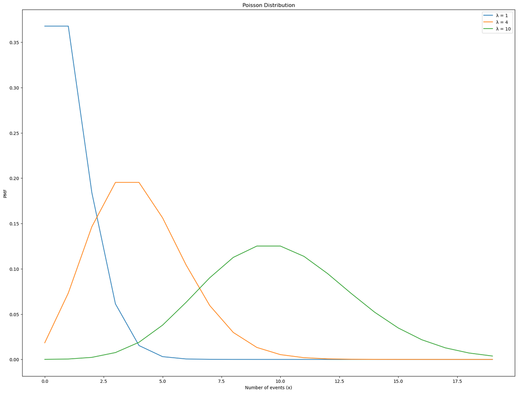

```python
# 5. Poisson Distribution (포아송 분포)
# 그래프 크기 설정
plt.figure(figsize=(20, 15))

x = np.arange(0, 20)
for lam in [1, 4, 10]:  # 평균 발생 횟수 λ 변화
    pmf = poisson.pmf(x, lam)
    plt.plot(x, pmf, label=f'λ = {lam}')
plt.title('Poisson Distribution')
plt.xlabel('Number of events (x)')
plt.ylabel('PMF')
plt.legend()
plt.show()
```

## 5. 지수분포 (Exponential Distribution)

- 포아송 과정에서 첫 사건이 발생할 때까지 걸린 시간에 대한 분포 $$ f(x) = \lambda e^{-\lambda x}, \quad x > 0 $$
- 기호: $X \sim \text{Exp}(1/\lambda)$
- 평균과 분산:
  - $E(X) = \frac{1}{\lambda}$
  - $Var(X) = \frac{1}{\lambda^2}$

**참고**

- $1/\lambda=\theta$ 식으로 표현하면 지수분포는 $f(x)=\theta^{-1} e^{-x/\theta}$이다.
- $\theta$는 평균시간을 의미하며 표기는 $X \sim Exp(\theta)$로 한다.

### 1. **지수분포의 성질**

지수분포는 **어떤 사건이 발생할 때까지 걸린 시간**을 모델링하는 연속형 확률 분포입니다. 주로 포아송 과정과 관련된 대기 시간이나 서비스 시간 분석에 사용됩니다. 지수분포의 확률 변수 $ X $가 평균이 $ 1/\lambda $인 분포를 따를 때, 그 적률 생성 함수(MGF), 평균, 분산은 다음과 같습니다.

- **적률 생성 함수 (MGF)**:

  지수분포의 적률 생성 함수는 다음과 같이 주어집니다:

  $$ M(t) = E(e^{tX}) = \frac{1}{1 - t/\lambda}, \quad t < \lambda $$

  이는 지수 분포의 확률 밀도 함수에서 도출된 결과입니다.
- **기대값** $ E(X) $:

  적률 생성 함수의 첫 번째 미분을 $ t = 0 $에서 계산하여 기대값을 구할 수 있습니다:

  $$ E(X) = M'(0) = \frac{1}{\lambda} $$
- **분산** $ \text{Var}(X) $:

  분산은 적률 생성 함수의 두 번째 미분을 사용하여 구할 수 있으며, 다음과 같이 계산됩니다:

  $$ \text{Var}(X) = M''(0) - [M'(0)]^2 = \frac{1}{\lambda^2} $$

따라서, 지수분포의 기대값은 $ 1/\lambda $, 분산은 $ 1/\lambda^2 $입니다.

### 2. **지수분포의 무기억성 (비기억성)**

**무기억성(Memoryless Property)** 은 지수분포의 중요한 성질 중 하나입니다. 이는 **과거가 현재나 미래의 결과에 영향을 미치지 않는** 특성을 말하며, 지수분포는 이를 만족하는 유일한 연속형 분포입니다.

지수분포에서 무기억성은 다음과 같이 표현됩니다:

- **확률 변수** $ X $가 지수분포를 따를 때:

  $$ P(X > x) = e^{-\lambda x} $$

  이는 사건이 $ x $ 시간 이후에 발생할 확률입니다.
- **무기억성**:

  과거에 $ s $ 시간 이상이 경과한 후, 앞으로 추가로 $ t $ 시간 이상이 더 경과할 확률은 처음부터 $ t $ 시간 이상 경과할 확률과 동일합니다. 수학적으로는 다음과 같이 표현됩니다:

  $$ P(X > s + t \mid X > s) = P(X > t) $$

  즉, 어떤 시간이 경과한 후에도 추가적인 대기 시간이 처음부터 대기했을 때와 동일하게 분포된다는 의미입니다.

이 성질은 다음과 같이 증명할 수 있습니다:

1. 조건부 확률의 정의를 사용하여 표현하면:

   $$ P(X > s + t \mid X > s) = \frac{P(X > s + t)}{P(X > s)} $$
2. 이를 지수분포의 특성에 대입하면:

   $$ P(X > s + t \mid X > s) = \frac{e^{-\lambda (s + t)}}{e^{-\lambda s}} = e^{-\lambda t} = P(X > t) $$

따라서, 지수분포는 무기억성(Memoryless Property)을 만족합니다.

### 3. **지수분포의 특성 요약**

- **적률 생성 함수**: $$ M(t) = \frac{1}{1 - t/\lambda}, \quad t < \lambda $$
- **기대값**: $$ E(X) = \frac{1}{\lambda} $$
- **분산**: $$ \text{Var}(X) = \frac{1}{\lambda^2} $$
- **무기억성**: $$ P(X > s + t \mid X > s) = P(X > t) $$

지수분포는 연속형 확률분포 중에서 **무기억성**을 가지는 유일한 분포입니다. 이는 과거에 대한 정보가 앞으로의 사건 발생에 영향을 미치지 않는다는 중요한 성질을 나타냅니다.

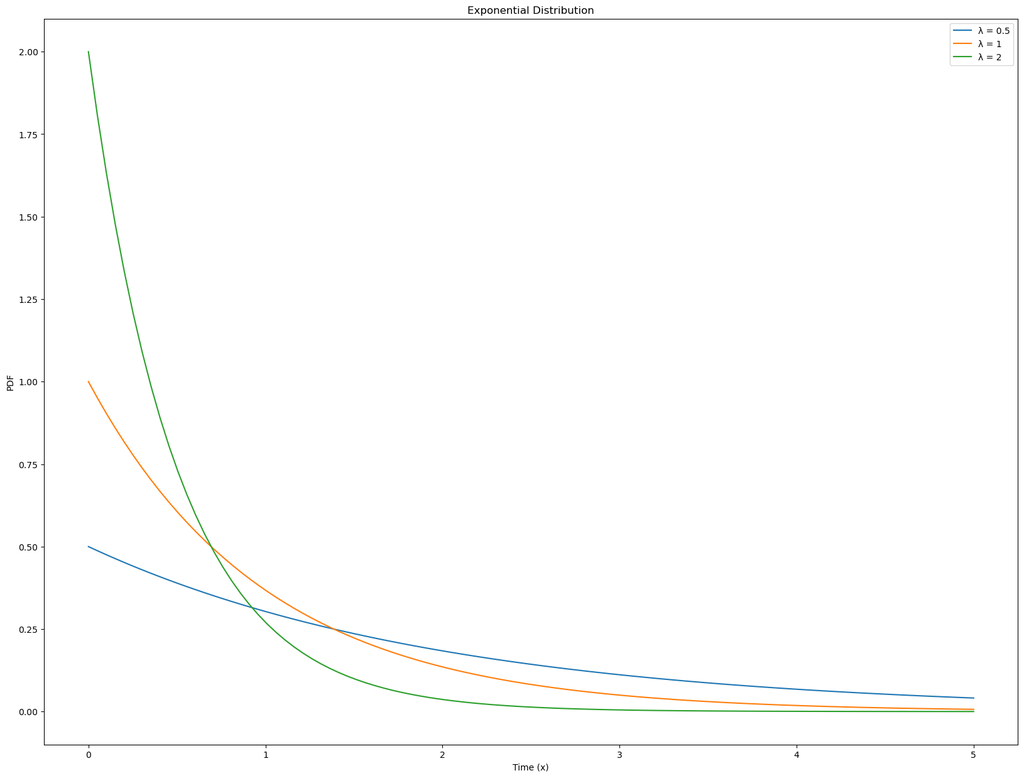

```python
# 6. Exponential Distribution (지수분포)
# 그래프 크기 설정
plt.figure(figsize=(20, 15))

x = np.linspace(0, 5, 100)
for lam in [0.5, 1, 2]:  # λ 변화
    pdf = expon.pdf(x, scale=1/lam)
    plt.plot(x, pdf, label=f'λ = {lam}')
plt.title('Exponential Distribution')
plt.xlabel('Time (x)')
plt.ylabel('PDF')
plt.legend()
plt.show()
```

## 감마분포 (일반적 정의)

지수분포의 확장: $n$번째 사건의 발생 시간

- **감마함수**: $$ \Gamma(\alpha) = \int_0^\infty y^{\alpha-1} e^{-y} dy, \quad \alpha > 0 $$
- **확률 밀도 함수 (pdf)**: $$ f(x) = (\Gamma(\alpha)\beta^\alpha)^{-1} x^{\alpha - 1} e^{-x/\beta}, \quad x > 0 $$
- **기호**: $$ X \sim \text{Gamma}(\alpha, \beta) $$
- **의미**:
  - $\alpha = 1$: 지수분포
  - $\alpha = n$: n번째 발생 시간 (형상모수)
  - $\beta = 1/\lambda$: 척도모수

## 감마분포의 성질 (정리 3.5.2)

- **적률 생성 함수** (M(t)): $$ M(t) = (1 - \beta t)^{-\alpha} $$
- **기대값** (E(X)): $$ E(X) = \alpha \beta $$
- **분산** (Var(X)): $$ \text{Var}(X) = \alpha \beta^2 $$
- **가법성 성립**: 감마분포는 가법성의 성질을 가집니다.

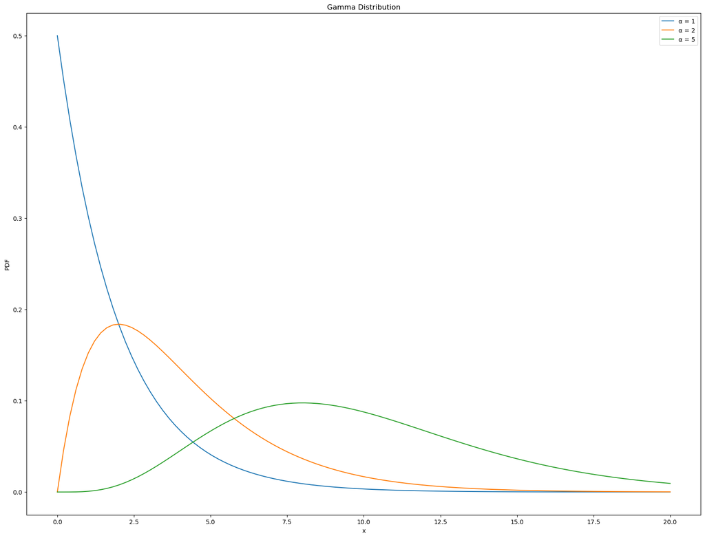

```python
# 7. Gamma Distribution (감마분포)
# 그래프 크기 설정
plt.figure(figsize=(20, 15))

x = np.linspace(0, 20, 100)
for alpha in [1, 2, 5]:  # α 변화
    pdf = gamma.pdf(x, a=alpha, scale=2)
    plt.plot(x, pdf, label=f'α = {alpha}')
plt.title('Gamma Distribution')
plt.xlabel('x')
plt.ylabel('PDF')
plt.legend()
plt.show()
```

## 7. 정규분포 (Normal Distribution)

- 이항분포의 극한으로 발견되었다.
  - De Moivre, Laplace
- 실험 오차의 분포 연구: Gauss
- 평균 $\mu$, 분산 $\sigma^2$인 정규분포 $$ f(x) = \frac{1}{\sqrt{2\pi \sigma^2}} e^{-(x-\mu)^2 / (2\sigma^2)} $$
- 기호: $X \sim N(\mu, \sigma^2)$

### 정규분포의 성질:

- 적률생성함수
  - $M(t)=E(e^{tX})=\exp(\mu t + \sigma^2 t^2 / 2)$
- 평균과 분산:
  - $E(X) = \mu$
  - $Var(X) = \sigma^2$
- 가법성이 성립한다.

#### 정규분포의 선형성과 표준화 성질

- 선형성: $aX + b \sim N(a\mu + b, a^2 \sigma^2)$
  - 적률생성함수 또한 동일하게 도출된다.
- 표준화: $Z=(X-\mu)/\sigma \sim N(0,1)$
  - 표준화 또한 일종의 선형변환
  - 표준화는 선형성의 특수한 경우

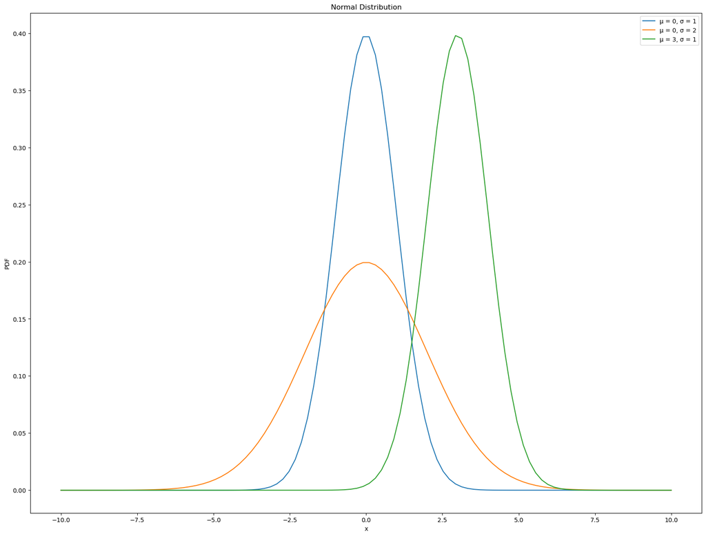

```python
# 8. Normal Distribution (정규분포)
# 그래프 크기 설정
plt.figure(figsize=(20, 15))

x = np.linspace(-10, 10, 100)
for mu, sigma in [(0, 1), (0, 2), (3, 1)]:  # μ와 σ 변화
    pdf = norm.pdf(x, mu, sigma)
    plt.plot(x, pdf, label=f'μ = {mu}, σ = {sigma}')
plt.title('Normal Distribution')
plt.xlabel('x')
plt.ylabel('PDF')
plt.legend()
plt.show()
```

## 8. 균등분포 (Uniform Distribution)

- 구간 [a, b]에서의 확률 밀도 함수: $$ f(x) = \frac{1}{b-a}, \quad a \leq x \leq b $$
- 기호: $X \sim U(a, b)$
- 평균과 분산:
  - $E(X) = \frac{a+b}{2}$
  - $Var(X) = \frac{(b-a)^2}{12}$
- 적률 생성 함수
  - $M(t) = \frac{(e^{bt}-e^{at})}{(b-a)t}$

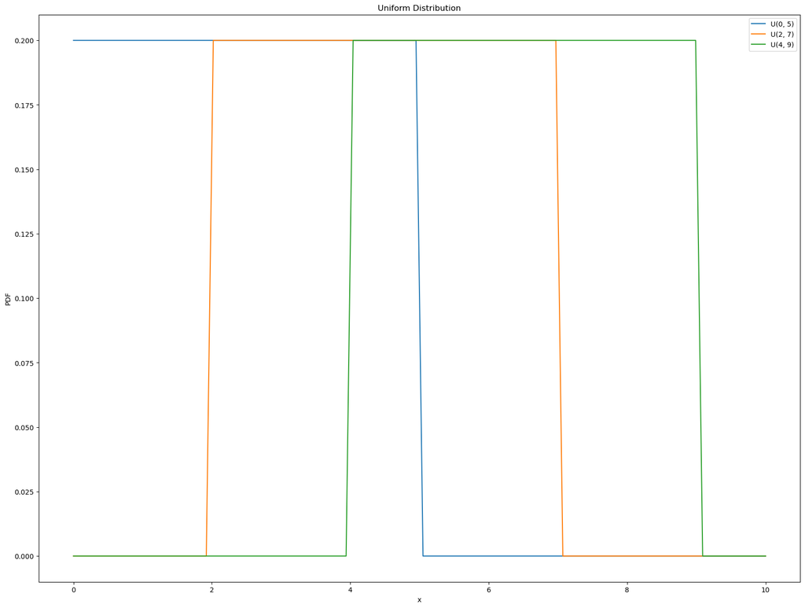

```python
# 9. Uniform Distribution (균등분포)
# 그래프 크기 설정
plt.figure(figsize=(20, 15))

x = np.linspace(0, 10, 100)
for a, b in [(0, 5), (2, 7), (4, 9)]:  # 구간 변화
    pdf = uniform.pdf(x, a, b - a)
    plt.plot(x, pdf, label=f'U({a}, {b})')
plt.title('Uniform Distribution')
plt.xlabel('x')
plt.ylabel('PDF')
plt.legend()
plt.show()
```

## 9. 카이제곱 분포 (Chi-Square Distribution)

- 자유도 $r$인 카이제곱 분포는 감마 분포의 특별한 경우로 정의됨 $$ f(x) = \frac{x^{r/2-1} e^{-x/2}}{2^{r/2} \Gamma(r/2)}, \quad x > 0 $$
- 기호: $X \sim \chi^2(r)$
- 평균과 분산:
  - $E(X) = r$
  - $Var(X) = 2r$

자유도 $r$의 카이제곱분포는 $Gamma(r/2, 2)$와 같다.

적률 생성 함수

- $(1-2t)^{-r/2}$

표준정규분포의 제곱합을 통해 정의하지만 감마분포의 특별한 경우인 것도 맞다.

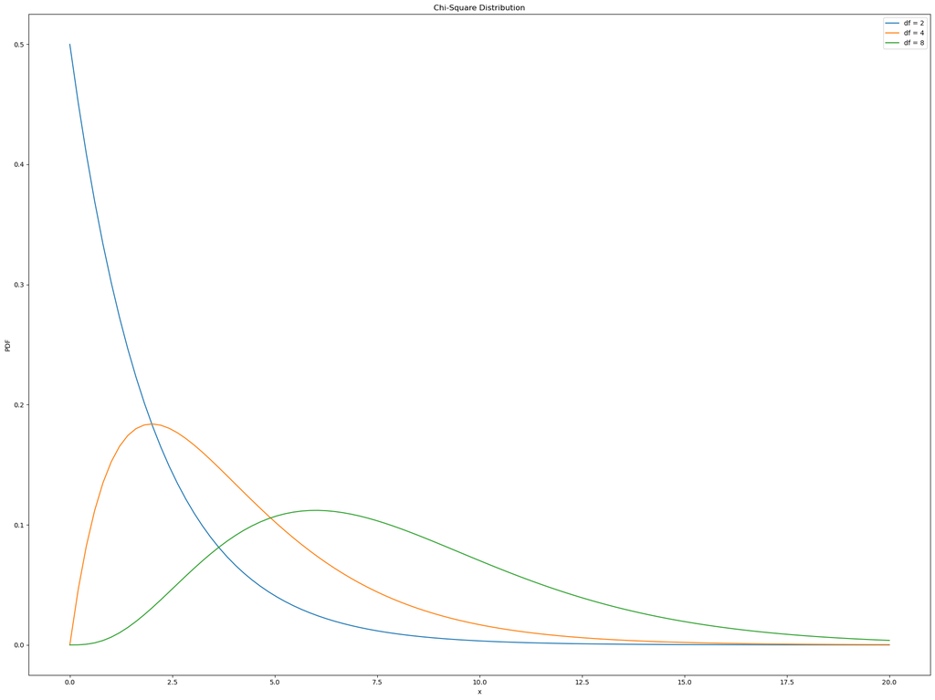

```python
# 10. Chi-Square Distribution (카이제곱 분포)
# 그래프 크기 설정
plt.figure(figsize=(20, 15))

x = np.linspace(0, 20, 100)
for df in [2, 4, 8]:  # 자유도 변화
    pdf = chi2.pdf(x, df)
    plt.plot(x, pdf, label=f'df = {df}')
plt.title('Chi-Square Distribution')
plt.xlabel('x')
plt.ylabel('PDF')
plt.legend()

plt.tight_layout()
plt.show()
```

# 사용례

각 분포를 활용한 통계 방법론이나 모델을 3개씩 나열해보겠습니다. 각 분포는 특정 데이터 특성에 맞게 다양한 통계적 방법론과 모델링 기법에 활용됩니다.

## 1. **초기하분포 (Hypergeometric Distribution)**

### 활용 방법론/모델:

1. **이항 분류 문제**: 초기하분포는 이항 분류 문제에서 모집단 내 특정 속성의 비율을 추정할 때 사용됩니다. 예를 들어, 품질 관리에서 불량품을 표본으로 검사할 때 사용됩니다.
2. **표본 추출 모델**: 복원 없이 추출하는 실험에서, 모집단에 있는 속성 개체의 확률을 구할 때 유용합니다. 예를 들어, 카드 게임에서 특정 카드가 나올 확률을 계산할 때 사용됩니다.
3. **유효성 평가**: 품질관리에서 모집단 내 결함이 있는 항목의 수를 추정하거나 특정 속성을 가진 항목을 추출할 확률을 평가하는 데 활용됩니다.

## 2. **베르누이 분포 (Bernoulli Distribution)**

### 활용 방법론/모델:

1. **로지스틱 회귀 모델**: 이항 결과(성공 또는 실패)를 예측하는 데 베르누이 분포가 사용됩니다. 이분법적 반응 변수를 가지는 회귀 모델에서 종속변수가 베르누이 분포를 따릅니다.
2. **베이지안 통계**: 베르누이 시행에서 성공 확률 $p$를 추정할 때 베이지안 방법론을 사용하여 사전 확률과 사후 확률을 계산하는 데 사용됩니다.
3. **이항 회귀**: 베르누이 분포는 이항 회귀의 기초로, 관측값이 두 가지 가능한 결과 중 하나를 갖는 경우 적용됩니다.

## 3. **이항분포 (Binomial Distribution)**

### 활용 방법론/모델:

1. **이항 검정**: 두 가지 범주 중 하나의 결과를 가지는 데이터를 기반으로 비율 차이를 검정하는 데 사용됩니다. 예를 들어, 신약 실험에서 성공/실패의 비율을 비교할 때 활용됩니다.
2. **포아송 회귀**: 희귀한 사건이 독립적으로 발생하는 경우, 이항분포는 포아송 분포로 근사될 수 있습니다. 이는 사고 빈도, 병원 방문 횟수 등의 예측에 사용됩니다.
3. **부트스트랩 추정**: 이항분포는 부트스트랩 샘플링에서 이항 확률의 신뢰구간을 계산하는 데 사용됩니다. 데이터의 불확실성을 추정하는 데 유용합니다.

## 4. **기하분포 (Geometric Distribution)**

### 활용 방법론/모델:

1. **생존 분석**: 특정 사건이 발생하기까지 걸리는 시간이나 시도 횟수를 모델링할 때 기하분포가 사용됩니다. 첫 성공까지의 횟수를 모델링하는 데 적합합니다.
2. **대기시간 모델**: 대기시간이 독립적이고 동일한 확률을 따르는 경우 기하분포를 사용해 다음 성공까지의 시도 수를 모델링할 수 있습니다.
3. **결점 검출**: 산업 공정에서 처음으로 결점이 발생할 때까지의 반복된 작업 횟수를 분석할 때 기하분포가 사용됩니다.

## 5. **포아송 분포 (Poisson Distribution)**

### 활용 방법론/모델:

1. **포아송 회귀**: 사건 발생 횟수를 예측하는 데 사용되며, 일반적으로 사고 빈도, 판매 건수, 방문 횟수 등 희소한 사건의 발생을 모델링합니다.
2. **대기열 모델링**: 대기열 이론에서 대기시간이나 서비스 횟수를 모델링하는 데 포아송 분포가 사용됩니다. 은행, 병원 등에서 고객이 도착하는 빈도를 예측할 수 있습니다.
3. **희귀 사건 분석**: 자연재해, 질병 발생, 교통사고 등 희귀한 사건의 발생 빈도를 모델링할 때 사용됩니다. 대규모 모집단에서 낮은 발생 확률을 가진 사건에 적합합니다.

## 6. **지수분포 (Exponential Distribution)**

### 활용 방법론/모델:

1. **생존 분석**: 특정 사건(예: 장비 고장, 사람의 사망)이 발생할 때까지의 시간(생존 시간)을 모델링하는 데 사용됩니다. 고장이 일정한 비율로 발생하는 상황을 잘 설명합니다.
2. **대기시간 모델**: 서비스 시스템에서 대기시간 분석에 자주 사용되며, 예를 들어 콜센터에서 다음 고객이 도착할 때까지의 시간을 모델링할 수 있습니다.
3. **신뢰성 분석**: 장비나 시스템의 고장률을 분석하는 신뢰성 이론에서 사용됩니다. 고장 시간이 지수분포를 따른다고 가정하는 경우가 많습니다.

## 7. **감마분포 (Gamma Distribution)**

### 활용 방법론/모델:

1. **생존 분석**: 생존 분석에서 생명 시간이 일정하지 않고 고장률이 시간에 따라 변할 때 감마분포가 사용됩니다.
2. **베이지안 추론**: 감마 분포는 포아송 분포와 결합된 베이지안 추론에서 사전 분포로 자주 사용됩니다. 이는 포아송-감마 모델에서 사후 분포로 나타납니다.
3. **보험 리스크 분석**: 감마 분포는 보험금 청구 금액을 모델링하거나 손실 분포를 추정하는 데 자주 사용됩니다.

## 8. **정규분포 (Normal Distribution)**

### 활용 방법론/모델:

1. **회귀 분석**: 정규분포는 회귀 분석에서 오차항이 정규분포를 따른다는 가정을 전제로 사용됩니다. 이를 통해 종속변수와 독립변수 사이의 관계를 분석합니다.
2. **가우시안 혼합 모델 (GMM)**: 군집 분석에서 정규분포의 혼합을 사용하여 데이터의 잠재 군집을 추정하는 데 사용됩니다. 데이터를 여러 정규분포로 설명할 수 있는 경우 유용합니다.
3. **ANOVA (분산 분석)**: 정규분포는 집단 간의 평균 차이를 분석하는 ANOVA에서 오차 항이 정규분포를 따른다는 가정 하에 사용됩니다.

## 9. **균등분포 (Uniform Distribution)**

### 활용 방법론/모델:

1. **몬테카를로 시뮬레이션**: 난수를 생성하여 확률적 문제를 해결할 때 균등분포가 사용됩니다. 이때 난수는 주어진 구간에서 동일한 확률을 가집니다.
2. **샘플링 기법**: 임의 표본 추출 시 각 데이터가 동일한 확률로 선택되도록 균등분포를 사용할 수 있습니다.
3. **난수 생성**: 알고리즘이나 시뮬레이션에서 균등분포를 기반으로 난수를 생성하여 다양한 확률 모형에 적용할 수 있습니다.

## 10. **카이제곱 분포 (Chi-Square Distribution)**

### 활용 방법론/모델:

1. **카이제곱 검정**: 독립성 검정이나 적합성 검정에서 사용됩니다. 관측된 데이터와 기대값 간의 차이를 검정할 때 자주 사용됩니다.
2. **분산 분석**: 카이제곱 분포는 ANOVA 분석에서 집단 간 변동을 분석할 때 사용됩니다. 집단 간 분산 차이를 평가하는 데 유용합니다.
3. **신뢰 구간 추정**: 모집단의 분산에 대한 신뢰구간을 추정하는 데 카이제곱 분포를 사용합니다. 이는 표본 분산과 모집단 분산의 관계를 설명할 때 활용됩니다.

이와 같이 각 분포는 통계적 방법론과 모델링에 다양하게 활용됩니다. 각 분포는 데이터의 특성에 따라 적합한 분석 기법을 선택하는 데 중요한 역할을 합니다.